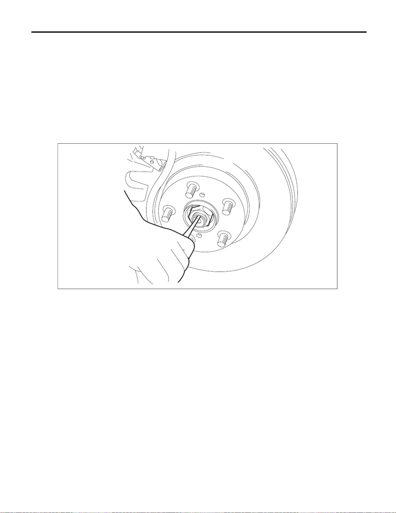

DS-64

Rear Drive Shaft

DRIVE SHAFT SYSTEM

8. Rear Drive Shaft

A: REMOVAL

1) Disconnect the ground cable from battery. <Ref. to NT-5, BATTERY, NOTE, Note.>

NOTE:

For models other than STI model, disconnect the ground terminal from battery sensor.

2) Lift up the vehicle, and then remove the rear wheels.

3) Remove the nut - axle.

CAUTION:

Do not loosen the nut - axle while the rear axle is loaded. Doing so may damage the hub unit COMPL.

(1) Lift the crimped section of the nut - axle.

(2) Remove the nut - axle using a socket wrench while depressing the brake pedal.

4) Remove the sensor assembly - headlight beam leveler. (Model with auto headlight beam leveler) <Ref. to

LI-74, REMOVAL, Rear Height Sensor.>

5) Disconnect the oil temperature sensor connector. (Model with oil temperature sensor)

6) Drain differential gear oil.

7) Remove the propeller shaft. <Ref. to DS-12, REMOVAL, Propeller Shaft.>

DS-00486

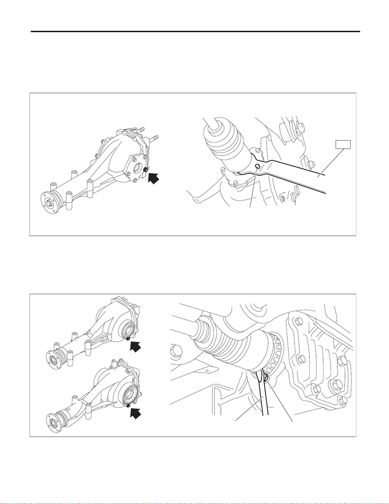

DS-65

Rear Drive Shaft

DRIVE SHAFT SYSTEM

8) Loosen the joint of rear differential assembly and rear drive shaft assembly.

• T type: Pull out the rear drive shaft assembly by fitting the ST to the bolt (a) as shown in the figure.

CAUTION:

Fit the ST to the bolts as shown in the figure to prevent damage of the side bearing retainer.

Preparation tool:

ST: DRIVE SHAFT REMOVER (28099PA100)

• VA type: Pull out the rear drive shaft assembly by fitting the tire lever (b) to the bolt (a) as shown in the figure.

CAUTION:

To prevent damage to the side bearing retainer, use by placing the tire lever against the bolt as

shown in the figure.

Preparation tool:

Tire lever

DS-00506

(a)

ST

(a)

DS-00508

(a)

(a)

(b)

(a)

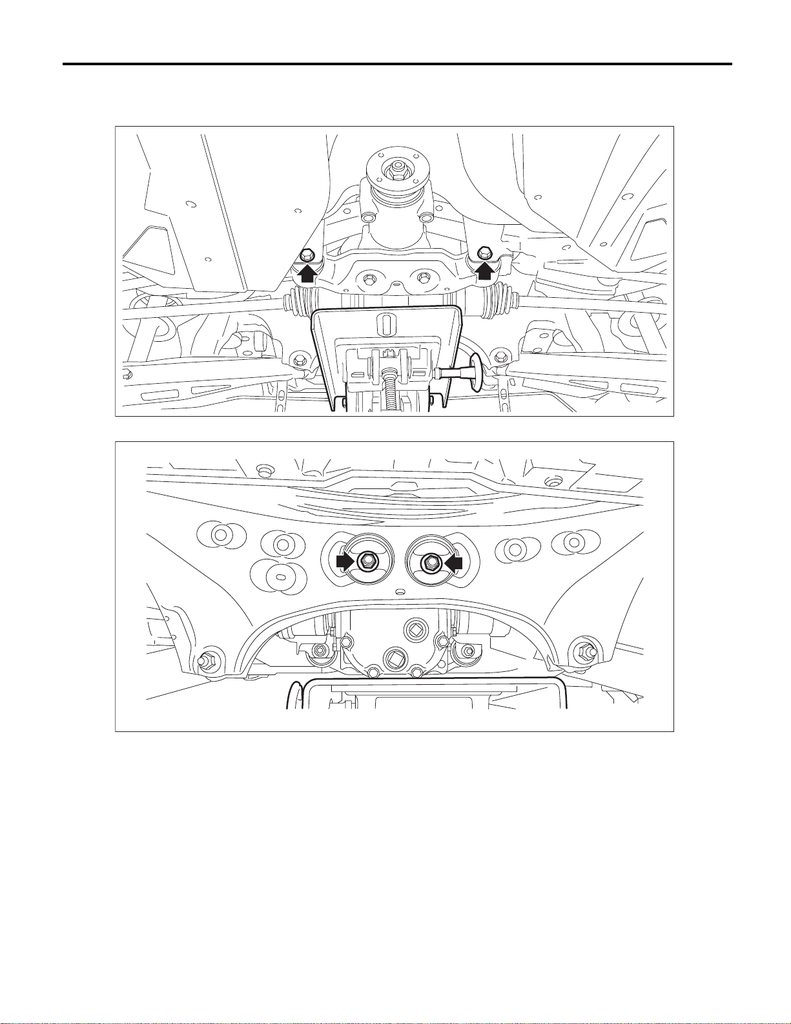

DS-66

Rear Drive Shaft

DRIVE SHAFT SYSTEM

9) Remove the installation section of rear differential assembly.

(1) Support the rear differential assembly with a transmission jack.

(2) Remove the bolts which hold the rear differential front crossmember from the rear sub frame assembly.

(3) Remove the self-locking nuts which hold the rear differential to the rear sub frame assembly.

DS-00615

DS-00572

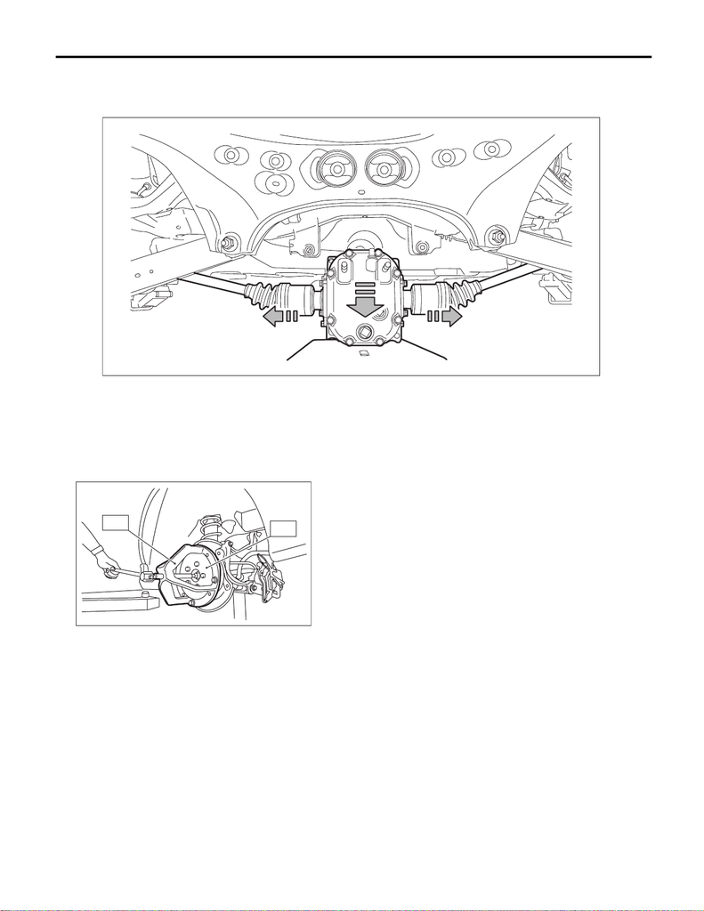

DS-67

Rear Drive Shaft

DRIVE SHAFT SYSTEM

10) Completely pull out the rear drive shaft assembly while lowering the rear differential.

CAUTION:

Pay attention to avoid damaging the boot of drive shaft.

11) Remove the rear drive shaft assembly from the housing assembly - rear axle.

NOTE:

If it is hard to remove, use the ST.

Preparation tool:

ST1: AXLE SHAFT PULLER (926470000)

ST2: AXLE SHAFT PULLER PLATE (28099PA110)

DS-00573

DS-00122

ST2

ST1

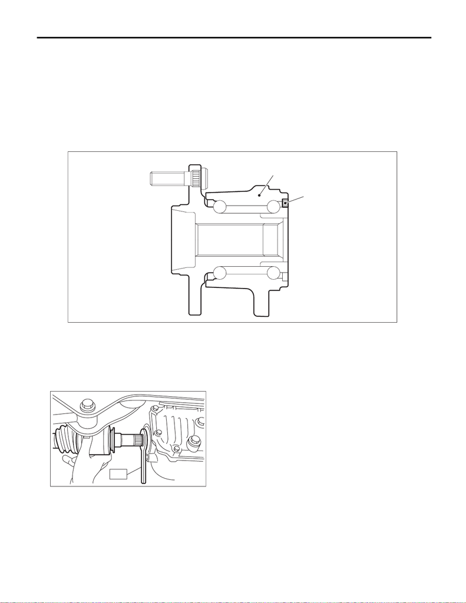

DS-68

Rear Drive Shaft

DRIVE SHAFT SYSTEM

B: INSTALLATION

1) Replace the rear differential side oil seal. <Ref. to DI-55, REPLACEMENT, Rear Differential Side Oil

Seal.>

NOTE:

After pulling out the drive shaft assembly, be sure to replace with a new oil seal.

2) Insert the drive shaft assembly into the rear hub spline, and pull it into the specified position.

CAUTION:

• Be careful not to damage the magnetic encoder.

• Do not get closer the tool which charged magnetism to magnetic encoder.

• Do not hammer the drive shaft assembly when installing.

3) Temporarily tighten the nut - axle.

4) Using the ST, install the rear drive shaft assembly to the rear differential.

Preparation tool:

ST: OIL SEAL PROTECTOR (28099PA090)

(1) Magnetic encoder (2) Hub unit COMPL - rear axle

DS-00498

(2)

(1)

ST

DI-00223

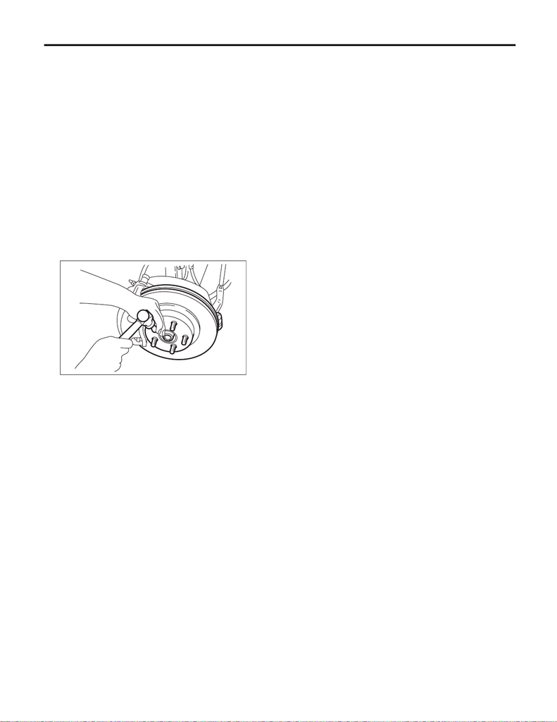

DS-69

Rear Drive Shaft

DRIVE SHAFT SYSTEM

5) Install the rear differential assembly to the rear sub frame assembly.

CAUTION:

Be sure to use a new self-locking nut.

Tightening torque:

Differential assembly — bushing - differential: 70 N·m (7.1 kgf-m, 51.6 ft-lb)

Differential assembly — rear sub frame assembly: 110 N·m (11.2 kgf-m, 81.1 ft-lb)

6) Install the sensor assembly - headlight beam leveler. (Model with auto headlight beam leveler)

Tightening torque:

7.5 N·m (0.8 kgf-m, 5.5 ft-lb)

7) Install the oil temperature sensor connector. (Model with oil temperature sensor)

8) While pressing the brake pedal, tighten the new axle nuts to the specified torque.

CAUTION:

Do not load the rear axle before tightening the nut - axle. Doing so may damage the hub unit COMPL.

Tightening torque:

190 N·m (19.4 kgf-m, 140.1 ft-lb)

9) Lock the nut - axle securely.

10) Fill differential gear oil.

11) Install the rear wheels.

Tightening torque:

120 N·m (12.2 kgf-m, 88.5 ft-lb)

12) Perform reinitialization of the auto headlight beam leveler system. (Model with auto headlight beam lev-

eler) <Ref. to LI-16, PROCEDURE, Auto Headlight Beam Leveler System.>

DS-00048

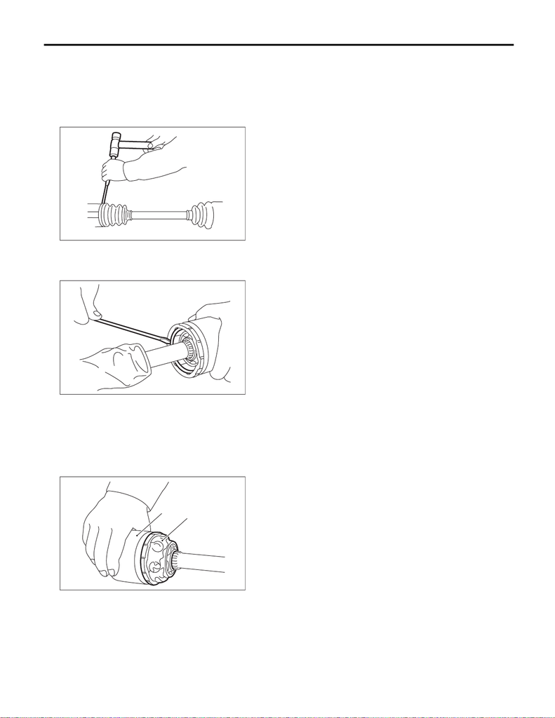

DS-70

Rear Drive Shaft

DRIVE SHAFT SYSTEM

C: DISASSEMBLY

1. EBJ + EDJ TYPE

1) Using a flat tip screwdriver or plier, loosen the boot band on the large end of EDJ boot.

CAUTION:

Be careful not to damage the boot.

2) Remove the boot band on the small end of EDJ boot in the same manner.

3) Remove the large end of EDJ boot from EDJ outer race.

4) Remove the round snap ring at the neck of EDJ outer race with a flat tip screwdriver.

5) Remove the EDJ outer race from shaft assembly.

6) Wipe off the grease and take out the ball bearings.

CAUTION:

The grease is a special grease (grease for constant velocity joints). Do not mix with other greases.

NOTE:

Disassemble the parts taking care not to lose balls.

DS-00124

DS-00125

(A) Outer race

(B) Grease

DS-00126

(B)

(A)

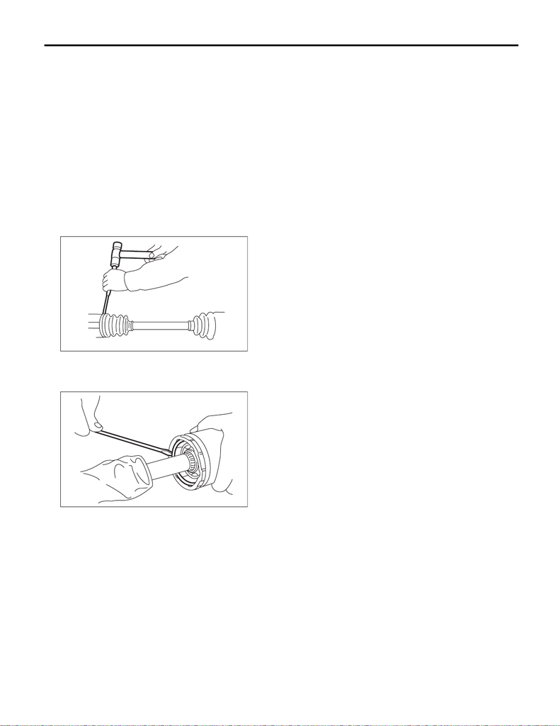

DS-71

Rear Drive Shaft

DRIVE SHAFT SYSTEM

7) To remove the cage from inner race, turn the cage by a half pitch to the track groove of inner race and shift

the cage.

8) Using pliers, remove the snap ring fixing the inner race to the shaft.

9) Take out the EDJ inner race.

10) Take off the EDJ cage from shaft and remove the EDJ boot.

CAUTION:

Wrap shaft splines with vinyl tape to protect the boot from scratches.

11) Remove the EBJ boot using the same procedures as for the EDJ boot.

NOTE:

The EBJ is a non-disassembly part, so the drive shaft disassembly stops here.

2. EBJ + DOJ TYPE

1) Using a flat tip screwdriver or plier, loosen the boot band on the large end of DOJ boot.

CAUTION:

Be careful not to damage the boot.

2) Remove the boot band on the small end of DOJ boot in the same manner.

3) Remove the large end of DOJ boot from DOJ outer race.

4) Remove the round snap ring at the neck of DOJ outer race with a flat tip screwdriver.

5) Take out the DOJ outer race from the shaft assembly.

DS-00124

DS-00125

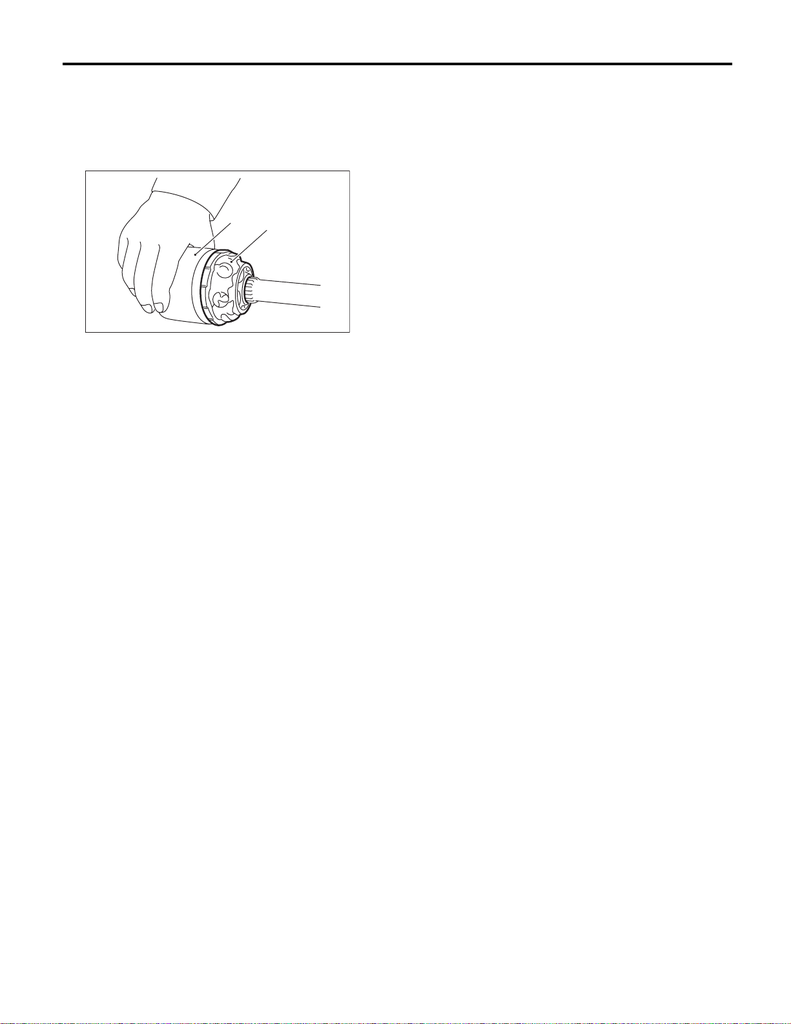

DS-72

Rear Drive Shaft

DRIVE SHAFT SYSTEM

6) Wipe off the grease and take out the ball bearings.

CAUTION:

The grease is a special grease (grease for constant velocity joints). Do not mix with other greases.

NOTE:

Disassemble the parts taking care not to lose balls.

7) To remove the cage from inner race, turn the cage by a half pitch to the track groove of inner race and shift

the cage.

8) Using pliers, remove the snap ring fixing the inner race to the shaft.

9) Take out the DOJ inner race.

10) Take off the DOJ cage from shaft and remove the DOJ boot.

CAUTION:

Wrap shaft splines with vinyl tape to protect the boot from scratches.

11) Remove the EBJ boot using the same procedures as for the DOJ boot.

NOTE:

The EBJ is a non-disassembly part, so the drive shaft disassembly stops here.

(A) Outer race

(B) Grease

DS-00126

(B)

(A)

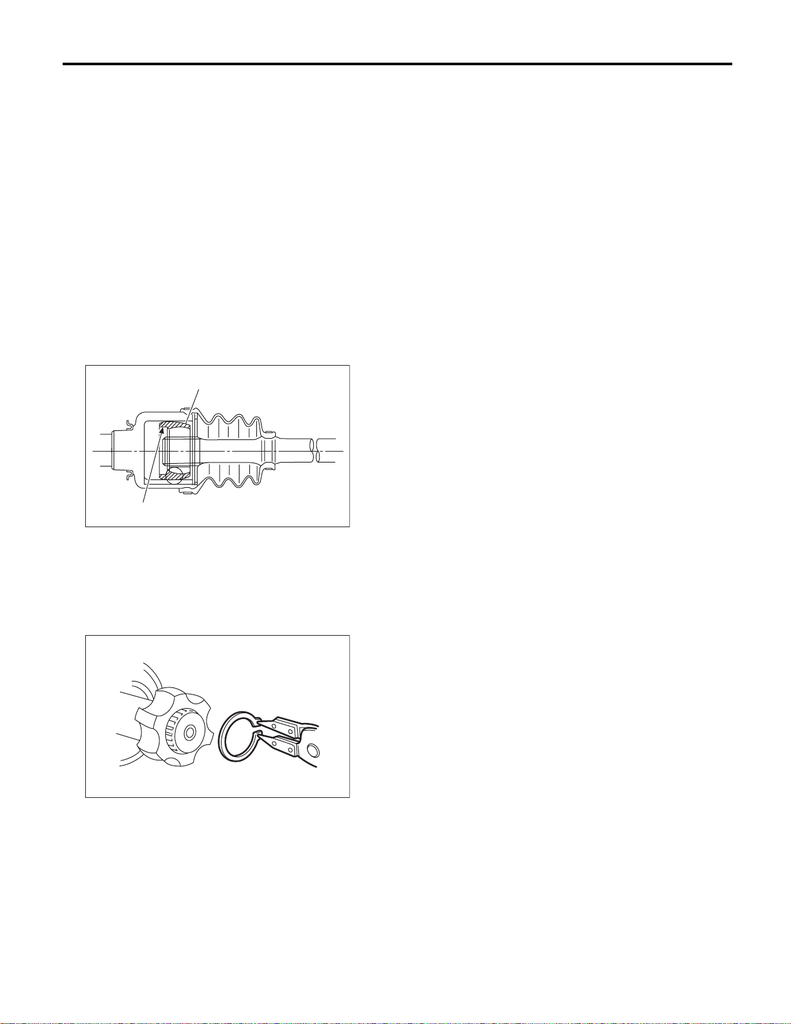

DS-73

Rear Drive Shaft

DRIVE SHAFT SYSTEM

D: ASSEMBLY

1. EBJ + EDJ TYPE

CAUTION:

Wrap shaft splines with vinyl tape to protect the boot from scratches.

NOTE:

Use specified grease.

EBJ side:

NKG814

EDJ side:

NKG814

1) Install the EBJ boot to the specified position, and fill it with 50 to 60 g (1.76 to 2.12 oz) of specified grease.

2) Place the EDJ boot at the center of shaft.

3) Insert the EDJ cage onto shaft.

NOTE:

Insert the cage with the cutout portion facing the shaft end, since the cage has an orientation.

4) Install the EDJ inner race on shaft and fix the snap ring in place with pliers.

NOTE:

Confirm that the snap ring is completely fitted in the shaft groove.

(A) Cage

(B) Cutout portion

DS-00395

(B)

(A)

DS-00128

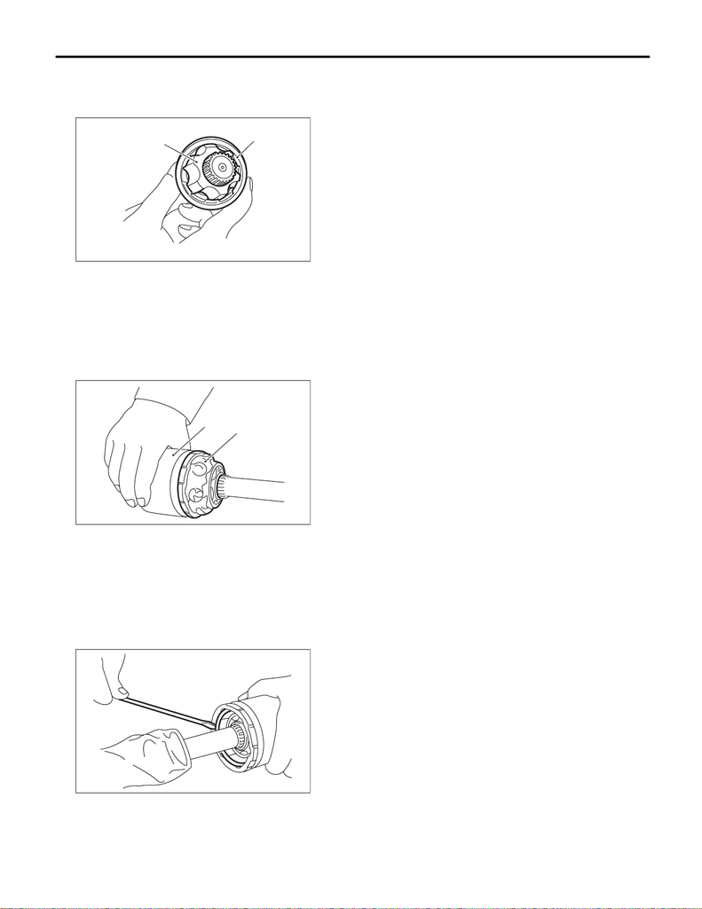

DS-74

Rear Drive Shaft

DRIVE SHAFT SYSTEM

5) Install the cage to inner race fixed upon shaft.

NOTE:

Fit the cage with the protruding section aligned with the track on the inner race, and turn by a half pitch.

6) Fill 80 to 90 g (2.82 to 3.17 oz) of specified grease into the inner side of the EDJ outer race.

7) Apply a thin coat of specified grease to the cage pocket and ball.

8) Insert the ball bearings into the cage pocket.

9) Align the outer race track and ball positions, and place the shaft, inner race, cage and ball bearings in the

original positions, and then fix outer race in place.

10) Install the snap ring in the groove on the EDJ outer race.

NOTE:

• Assure that the balls, cage and inner race are completely fitted in the outer race of EDJ.

• Use care not to place the matched position of snap ring in the ball groove of outer race.

• Pull the shaft lightly and assure that the circlip is completely fitted in the groove.

(A) Inner race

(B) Cage

DS-00129

(B)

(A)

(A) Outer race

(B) Grease

DS-00126

(B)

(A)

DS-00125

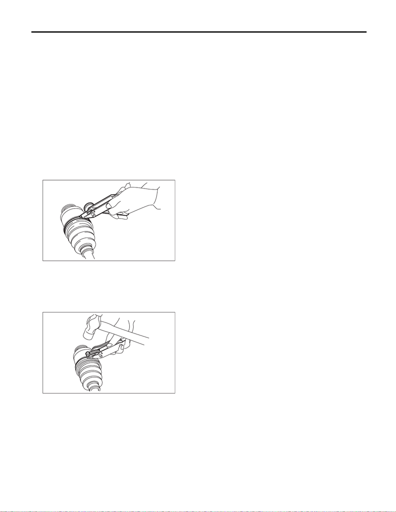

DS-75

Rear Drive Shaft

DRIVE SHAFT SYSTEM

11) Apply an even coat of the specified grease [20 to 30 g (0.71 to 1.06 oz)] to the entire inner surface of boot.

Also apply grease to the shaft.

12) Install the EDJ boot taking care not to twist it.

NOTE:

• The inside of the large end of EDJ boot and the boot groove shall be cleaned so as to be free from grease

and other substances.

• When installing the EDJ boot, position the outer race of EDJ at center of the stroke.

13) Put a new band through the clip and wind twice in the band groove of the boot.

14) Pinch the end of band with pliers. Hold the clip and tighten securely.

NOTE:

When tightening boot, use care so that the air within the boot is appropriate.

15) Tighten the band using the ST.

Preparation tool:

ST: BAND TIGHTENING TOOL (925091000)

NOTE:

Tighten the band until it cannot be moved by hand.

16) Tap the clip with the punch provided at the end of the ST.

Preparation tool:

ST: BAND TIGHTENING TOOL (925091000)

NOTE:

Tap to an extent that the boot underneath is not damaged.

17) Cut off the band with an allowance of about 10 mm (0.39 in) left from the clip and bend this allowance

over the clip.

NOTE:

Be careful so that the end of the band is in close contact with clip.

18) Install the EBJ boot using the same procedures as for the EDJ boot.

19) Extend and retract the EDJ repeatedly to provide an equal coating of grease.

DS-00132

DS-00133

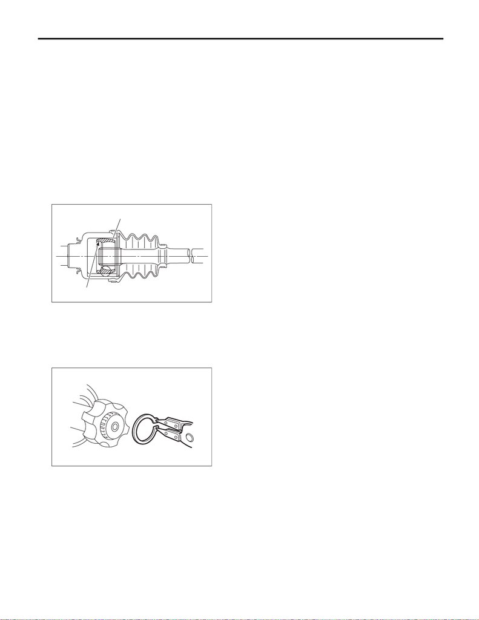

DS-76

Rear Drive Shaft

DRIVE SHAFT SYSTEM

2. EBJ + DOJ TYPE

CAUTION:

Wrap shaft splines with vinyl tape to protect the boot from scratches.

NOTE:

Use specified grease.

EBJ side:

NKG814

DOJ side:

NKG814

1) Install the EBJ boot to the specified position, and fill it with 50 to 60 g (1.76 to 2.12 oz) of specified grease.

2) Place the DOJ boot at the center of shaft.

3) Insert the DOJ cage onto shaft.

NOTE:

Insert the cage with the cutout portion facing the shaft end, since the cage has an orientation.

4) Install the DOJ inner race on shaft and fix the snap ring in place with pliers.

NOTE:

Confirm that the snap ring is completely fitted in the shaft groove.

(A) Cage

(B) Cutout portion

DS-00395

(B)

(A)

DS-00128

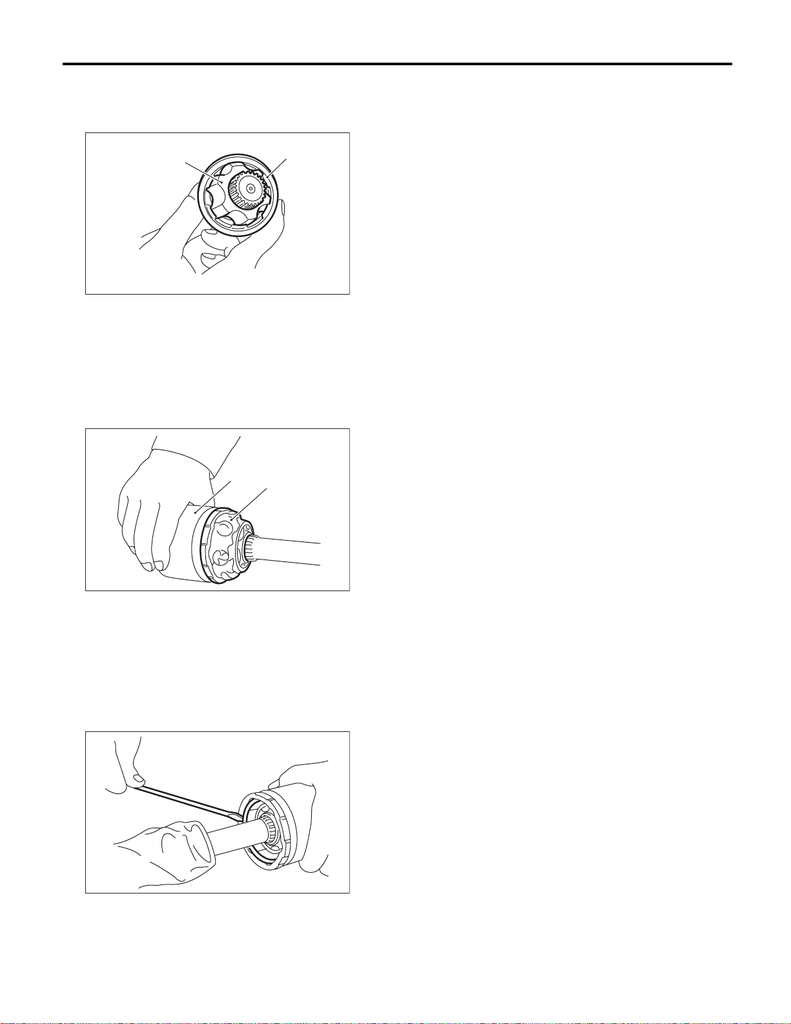

DS-77

Rear Drive Shaft

DRIVE SHAFT SYSTEM

5) Install the cage to inner race fixed upon shaft.

NOTE:

Fit the cage with the protruding section aligned with the track on the inner race, and turn by a half pitch.

6) Fill 80 to 90 g (2.82 to 3.17 oz) of specified grease into the inner side of the DOJ outer race.

7) Apply a thin coat of specified grease to the cage pocket and ball.

8) Insert the ball bearings into the cage pocket.

9) Align the outer race track and ball positions, and place the shaft, inner race, cage and ball bearings in the

original positions, and then fix outer race in place.

10) Install the snap ring in the groove on the DOJ outer race.

NOTE:

• Assure that the balls, cage and inner race are completely fitted in the outer race of DOJ.

• Use care not to place the matched position of snap ring in the ball groove of outer race.

• Pull the shaft lightly and assure that the circlip is completely fitted in the groove.

(A) Inner race

(B) Cage

DS-00129

(B)

(A)

(A) Outer race

(B) Grease

DS-00126

(B)

(A)

DS-00125

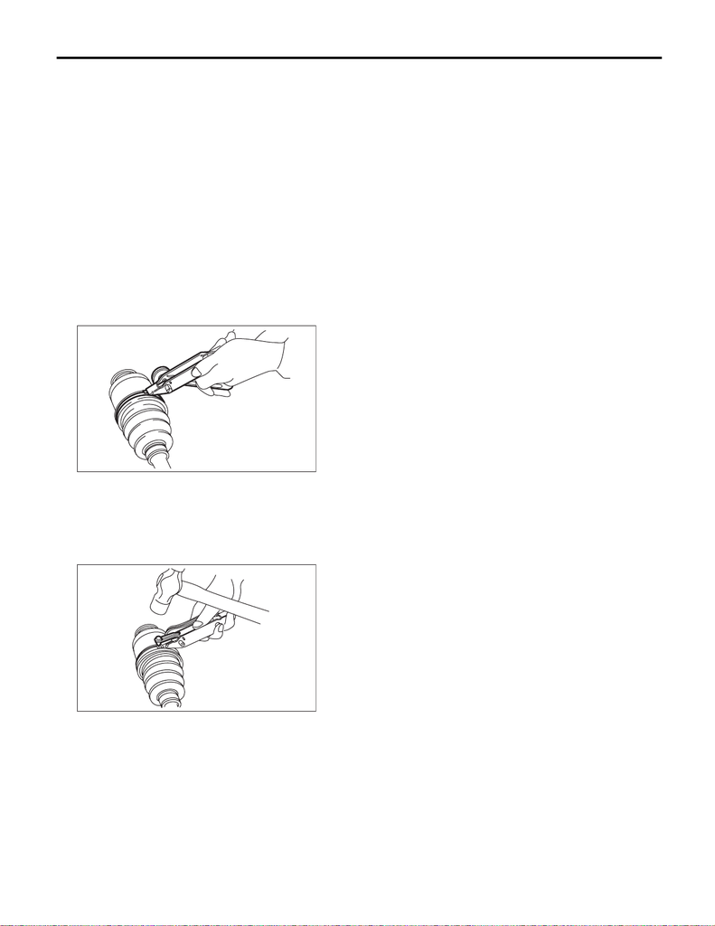

DS-78

Rear Drive Shaft

DRIVE SHAFT SYSTEM

11) Apply an even coat of the specified grease [20 to 30 g (0.71 to 1.06 oz)] to the entire inner surface of boot.

Also apply grease to the shaft.

12) Install the DOJ boot taking care not to twist it.

NOTE:

• The inside of the large end of DOJ boot and the boot groove shall be cleaned so as to be free from grease

and other substances.

• When installing the DOJ boot, position the outer race of DOJ at center of the stroke.

13) Put a new band through the clip and wind twice in the band groove of the boot.

14) Pinch the end of band with pliers. Hold the clip and tighten securely.

NOTE:

When tightening boot, use care so that the air within the boot is appropriate.

15) Tighten the band using the ST.

Preparation tool:

ST: BAND TIGHTENING TOOL (925091000)

NOTE:

Tighten the band until it cannot be moved by hand.

16) Tap the clip with the punch provided at the end of the ST.

Preparation tool:

ST: BAND TIGHTENING TOOL (925091000)

NOTE:

Tap to an extent that the boot underneath is not damaged.

17) Cut off the band with an allowance of about 10 mm (0.39 in) left from the clip and bend this allowance

over the clip.

NOTE:

Be careful so that the end of the band is in close contact with clip.

18) Install the EBJ boot using the same procedures as for the DOJ boot.

19) Extend and retract the DOJ repeatedly to provide an equal coating of grease.

DS-00132

DS-00133

[figure not shown]

DS-79

Rear Drive Shaft

DRIVE SHAFT SYSTEM

E: INSPECTION

Check the removed parts for damage, wear, corrosion etc. Repair or replace if defective.

• EDJ (High-Efficiency Compact Double Offset Joint):

Check for seizure, corrosion, damage, wear and excessive play.

• DOJ (Double Offset Joint):

Check for seizure, corrosion, damage, wear and excessive play.

• EBJ (high-efficiency compact ball fixed joint)

Check for seizure, corrosion, damage and excessive play.

• Shaft:

Check for excessive bending, twisting, damage and wear.

• Boot:

Check for wear, warping, breakage and scratches.

• Grease:

Check for discoloration and fluidity.